# E-news Express Study

## Background:

An online news portal aims to expand its business by acquiring new subscribers. Every visitor to the website takes certain actions based on their interest. The company plans to analyze these interests and wants to determine whether a new feature will be effective or not. Companies often analyze users' responses to two variants of a product to decide which of the two variants is more effective. This experimental technique is known as a/b testing that is used to determine whether a new feature attracts users based on a chosen metric.

Suppose you are hired as a Data Scientist in E-news Express. The design team of the company has created a new landing page. You have been assigned the task to decide whether the new landing page is more effective to gather new subscribers. Suppose you randomly selected 100 users and divided them equally into two groups. The old landing page is served to the first group (control group) and the new landing page is served to the second group (treatment group). Various data about the customers in both groups are collected in 'abtest.csv'. Perform the statistical analysis to answer the following questions using the collected data.

## Objective:

To study statistical analysis of business data. Explore the dataset and extract insights from the data. The idea is for you to get comfortable with doing statistical analysis in Python.

## Key Questions:

To perform the statistical analysis and visual analysis:

1. Explore the dataset and extract insights using Exploratory Data Analysis.
2. Do the users spend more time on the new landing page than the old landing page?
3. Is the conversion rate (the proportion of users who visit the landing page and get converted) for the new page greater than the conversion rate for the old page?
4. Does the converted status depend on the preferred language? [Hint: Create a contingency table using the pandas.crosstab() function]
5. Is the mean time spent on the new page same for the different language users? *Consider a significance level of 0.05 for all tests.

## Data Description:

- user_id - This represents the user ID of the person visiting the website.
- group - This represents whether the user belongs to the first group (control) or the second group (treatment).
- landing_page - This represents whether the landing page is new or old.
- time_spent_on_the_page - This represents the time (in minutes) spent by the user on the landing page.
- converted - This represents whether the user gets converted to a subscriber of the news portal or not.
- language_preferred - This represents the language chosen by the user to view the landing page.

### Import the required packages - pandas, numpy, seaborn, matplotlib.pyplot

```python
# Library to suppress warnings or deprecation notes
import warnings
warnings.filterwarnings('ignore')
```

```python
# Libraries to help with reading and manipulating data
import pandas as pd #library used for data manipulation and analysis
import numpy as np # library used for working with arrays.
import matplotlib.pyplot as plt

# Libraries to help with data visualization
import seaborn as sns # library for visualisations
import matplotlib.pyplot as plt # library for plots and visualisations
%matplotlib inline

# Library contains a large number of probability distributions as well as a growing library of statistical functions.
import scipy.stats as stats
```

```python
# install the scipy version 1.6.1. and restart the kernel after the successful installation
!pip install scipy==1.6.1
```

```python
# import the scipy and check the version to be sure that the version is 1.6.1.
import scipy
scipy.__version__
```

```
'1.6.1'
```

### Load the dataset

```python
data = pd.read_csv('abtest.csv')
```

```python
# copying data to another varaible to avoid any changes to original data
df = data.copy()
```

### View the first few rows of the dataset

```python
# looking at head (5 observations)
df.head()
```

|  | user_id | group | landing_page | time_spent_on_the_page | converted | language_preferred |
| --- | --- | --- | --- | --- | --- | --- |
| 0 | 546592 | control | old | 3.48 | no | Spanish |
| 1 | 546468 | treatment | new | 7.13 | yes | English |
| 2 | 546462 | treatment | new | 4.40 | no | Spanish |
| 3 | 546567 | control | old | 3.02 | no | French |
| 4 | 546459 | treatment | new | 4.75 | yes | Spanish |

**Observations**

- group, landing_page, converted and language_preferred variables are categorical variable.
- time_spent_on_the_page is a numerical variable.

### Check the shape of the dataset

```python
df.shape
```

```
(100, 6)
```

- The dataset has 100 rows and 6 columns.

### Check the info()

```python
df.info()
```

```
<class 'pandas.core.frame.DataFrame'>
RangeIndex: 100 entries, 0 to 99
Data columns (total 6 columns):
 #   Column                  Non-Null Count  Dtype
---  ------                  --------------  -----
 0   user_id                 100 non-null    int64
 1   group                   100 non-null    object
 2   landing_page            100 non-null    object
 3   time_spent_on_the_page  100 non-null    float64
 4   converted               100 non-null    object
 5   language_preferred      100 non-null    object
dtypes: float64(1), int64(1), object(4)
memory usage: 4.8+ KB
```

**Observations**

- group, landing_page, converted and language_preferred should be categorical variables
- no missing value observed

# Data Preprocessing

### Fixing the datatypes

```python
# categorical column should be converted to categorical type
# (It reduces the data space required to store the dataframe,
# every class in the categorical column will be represented by a number under the hood.
# This is useful during model building)

df['group'] = df.group.astype('category')
df['landing_page'] = df.landing_page.astype('category')
df['converted'] = df.converted.astype('category')
df['language_preferred'] = df.language_preferred.astype('category')
```

```python
df.info()
```

```
<class 'pandas.core.frame.DataFrame'>
RangeIndex: 100 entries, 0 to 99
Data columns (total 6 columns):
 #   Column                  Non-Null Count  Dtype
---  ------                  --------------  -----
 0   user_id                 100 non-null    int64
 1   group                   100 non-null    category
 2   landing_page            100 non-null    category
 3   time_spent_on_the_page  100 non-null    float64
 4   converted               100 non-null    category
 5   language_preferred      100 non-null    category
dtypes: category(4), float64(1), int64(1)
memory usage: 2.6 KB
```

- There are 2 numeric columns and 4 categorical columns

### Summary of the data

```python
df.describe().T
```

|  | count | mean | std | min | 25% | 50% | 75% | max |
| --- | --- | --- | --- | --- | --- | --- | --- | --- |
| user_id | 100.0 | 546517.0000 | 52.295779 | 546443.00 | 546467.75 | 546492.500 | 546567.2500 | 546592.00 |
| time_spent_on_the_page | 100.0 | 5.3778 | 2.378166 | 0.19 | 3.88 | 5.415 | 7.0225 | 10.71 |

- The time_spent_on_the_page has a wide range

**By default the describe() function shows only the summary of numeric variables only. Let's check the summary of non-numeric variables.**

```python
df.describe(exclude='number').T
```

|  | count | unique | top | freq |
| --- | --- | --- | --- | --- |
| group | 100 | 2 | control | 50 |
| landing_page | 100 | 2 | new | 50 |
| converted | 100 | 2 | yes | 54 |
| language_preferred | 100 | 3 | French | 34 |

**Observations**

- The variable 'language_preferred' has 3 unique categories and French has the highest frequency(34)

**Let's check the count of each unique category in each of the categorical variables.**

```python
#Making a list of all catrgorical variables
cat_col=['group', 'landing_page', 'converted', 'language_preferred']

#Printing number of count of each unique value in each column
for column in cat_col:
    print(df[column].value_counts())
    print('-'*50)
```

```
control      50
treatment    50
Name: group, dtype: int64
--------------------------------------------------
new    50
old    50
Name: landing_page, dtype: int64
--------------------------------------------------
yes    54
no     46
Name: converted, dtype: int64
--------------------------------------------------
French     34
Spanish    34
English    32
Name: language_preferred, dtype: int64
--------------------------------------------------
```

- All the categories in the group and landing_page variables has an equal count which mean that
  1. half of the user belongs to the first group (control) and other half to the seecond group (treatment),
  2. it also indiate that half of the landing page is new and ohter half is old.
- The number of yes observations is higher than no observations which represents that more user gets converted to a subscriber of the news portal
- Equal number of users chosen French and Spanish for preferred language which is higher (34) comapred to English (32)

```python
df.describe(include='all').T
```

|  | count | unique | top | freq | mean | std | min | 25% | 50% | 75% | max |
| --- | --- | --- | --- | --- | --- | --- | --- | --- | --- | --- | --- |
| user_id | 100.0 | NaN | NaN | NaN | 546517.0 | 52.295779 | 546443.0 | 546467.75 | 546492.5 | 546567.25 | 546592.0 |
| group | 100 | 2 | control | 50 | NaN | NaN | NaN | NaN | NaN | NaN | NaN |
| landing_page | 100 | 2 | new | 50 | NaN | NaN | NaN | NaN | NaN | NaN | NaN |
| time_spent_on_the_page | 100.0 | NaN | NaN | NaN | 5.3778 | 2.378166 | 0.19 | 3.88 | 5.415 | 7.0225 | 10.71 |
| converted | 100 | 2 | yes | 54 | NaN | NaN | NaN | NaN | NaN | NaN | NaN |
| language_preferred | 100 | 3 | French | 34 | NaN | NaN | NaN | NaN | NaN | NaN | NaN |

### Missing value treatment

```python
# checking missing values
df.isna().sum()
```

```
user_id                   0
group                     0
landing_page              0
time_spent_on_the_page    0
converted                 0
language_preferred        0
dtype: int64
```

- There are no missing values observed

```python
df.isnull().sum()
```

```
user_id                   0
group                     0
landing_page              0
time_spent_on_the_page    0
converted                 0
language_preferred        0
dtype: int64
```

- There are no missing values in the data

# EDA

### Let us explore the numerical variables first

```python
# While doing uni-variate analysis of numerical variables we want to study their central tendency
# and dispersion.
# Let us write a function that will help us create a boxplot and histogram for any input numerical
# variable.
# This function takes the numerical column as the input and returns the boxplots
# and histograms for the variable.
# Let us see if this helps us write faster and cleaner code.
def histogram_boxplot(feature, figsize=(15,10), bins = None):
    """ Boxplot and histogram combined
    feature: 1-d feature array
    figsize: size of fig (default (9,8))
    bins: number of bins (default None / auto)
    """
    f2, (ax_box2, ax_hist2) = plt.subplots(nrows = 2, # Number of rows of the subplot grid= 2
                                           sharex = True, # x-axis will be shared among all subplots
                                           gridspec_kw = {"height_ratios": (.25, .75)},
                                           figsize = figsize
                                           ) # creating the 2 subplots
    sns.boxplot(feature, ax=ax_box2, showmeans=True, color='red') # boxplot will be created and a star will indicate the mean value of the column
    sns.distplot(feature, kde=F, ax=ax_hist2, bins=bins) if bins else sns.distplot(feature, kde=False, ax=ax_hist2) # For histogram
    ax_hist2.axvline(np.mean(feature), color='g', linestyle='--') # Add mean to the histogram
    ax_hist2.axvline(np.median(feature), color='black', linestyle='-') # Add median to the histogram
```

## Observations on time_spent_on_the_page

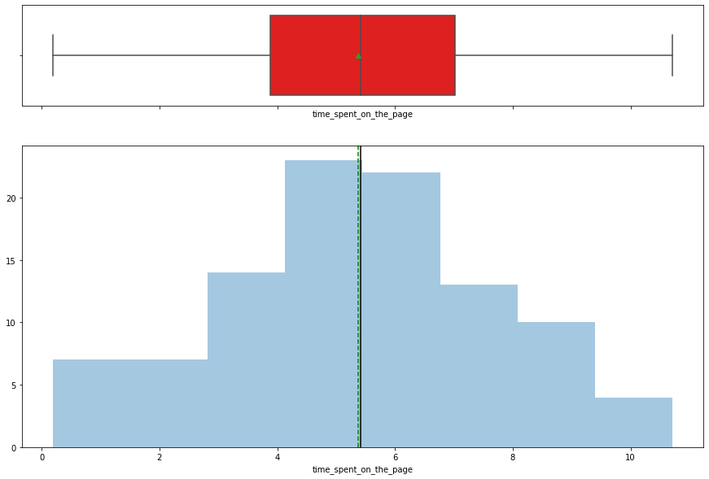

```python
histogram_boxplot(df.time_spent_on_the_page)
```

**Observations**

## Let's explore the categorical variables now

```python
# Function to create barplots that indicate percentage for each category.
def bar_perc(plot, feature):
    '''
    plot
    feature: 1-d categorical feature array
    '''
    total = len(feature) # length of the column
    for p in ax.patches:
        percentage = '{:.1f}%'.format(100 * p.get_height()/total) # percentage of each class of the category
        x = p.get_x() + p.get_width() / 2 - 0.05 # width of the plot
        y = p.get_y() + p.get_height()           # hieght of the plot
        ax.annotate(percentage, (x, y), size = 12) # annotate the percantage
```

## Observations on group

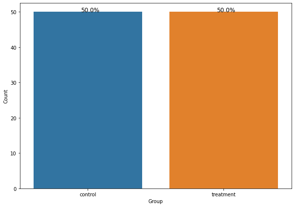

```python
plt.figure(figsize=(10,7))
ax = sns.countplot(df['group'])
plt.xlabel('Group')
plt.ylabel('Count')
bar_perc(ax,df['group'])
```

**Observations**

- Half of the group is control and other half is treatment

## Observations on landing_page

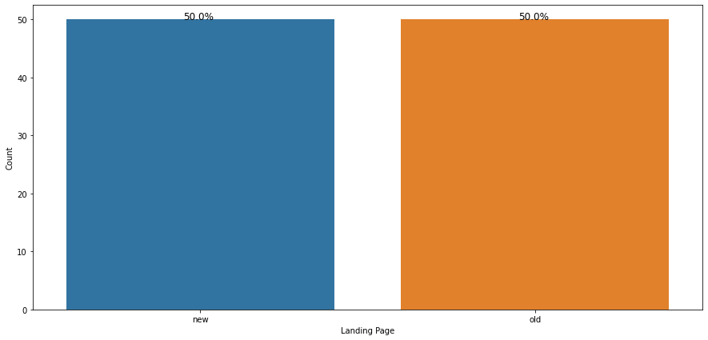

```python
plt.figure(figsize=(15,7))
ax = sns.countplot(df['landing_page'])
plt.xlabel('Landing Page')
plt.ylabel('Count')
bar_perc(ax,df['landing_page'])
```

- Half of the landig pages are new and ohter half are old

## Observations on converted

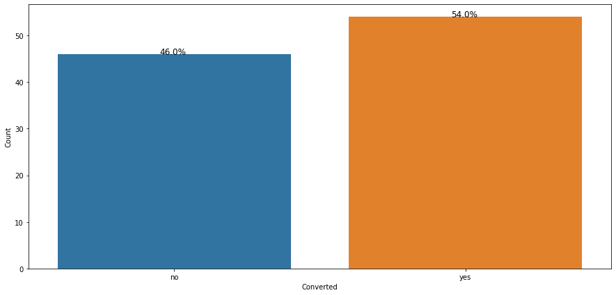

```python
plt.figure(figsize=(15,7))
ax = sns.countplot(df['converted'])
plt.xlabel('Converted')
plt.ylabel('Count')
bar_perc(ax,df['converted'])
```

- 54% gets converted to a new subscriber of the news portal

## Observations on language preferred

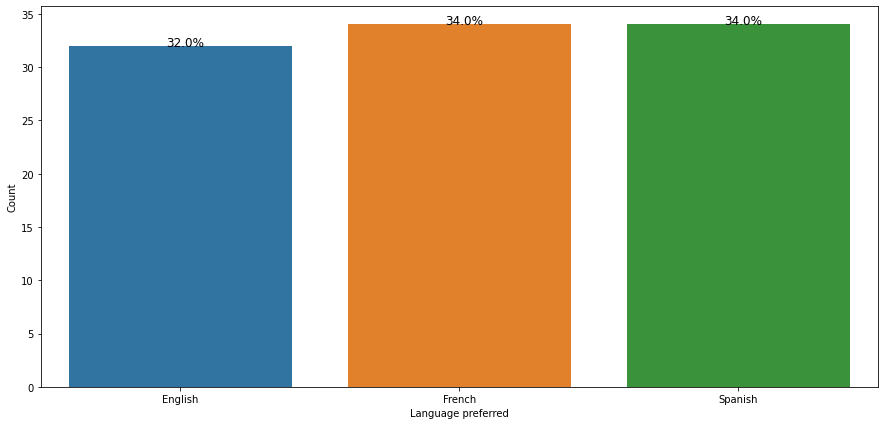

```python
plt.figure(figsize=(15,7))
ax = sns.countplot(df['language_preferred'])
plt.xlabel('Language preferred')
plt.ylabel('Count')
bar_perc(ax,df['language_preferred'])
```

- 32% user chose English language to view the page, whereas 34% user chose French and Spanish

## Bivariate Analysis

**Plot bivariate charts between variables to understand their interaction with each other.**

#### time_spent_on_the_page of user group

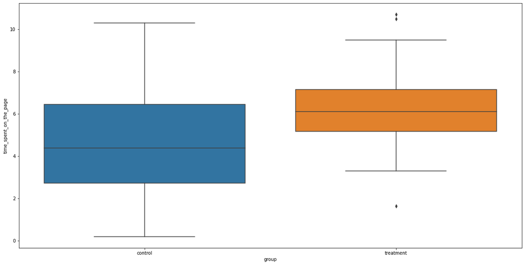

```python
plt.figure(figsize=(20,10))
sns.boxplot(df['group'],df['time_spent_on_the_page'])
plt.ylabel('time_spent_on_the_page')
plt.xlabel('group')
plt.show()
```

**Observations**

#### time_spent_on_the_page vs landing_page

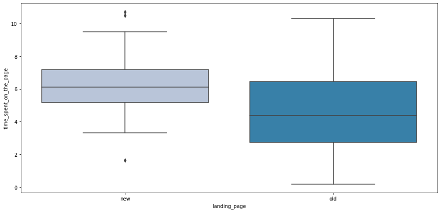

```python
plt.figure(figsize=(15,7))
sns.boxplot(df["landing_page"],df["time_spent_on_the_page"],palette="PuBu")
plt.show()
```

**Observations**

- Users are spenting their time more on new landing page as compared to old landing page

#### time_spent_on_the_page vs converted

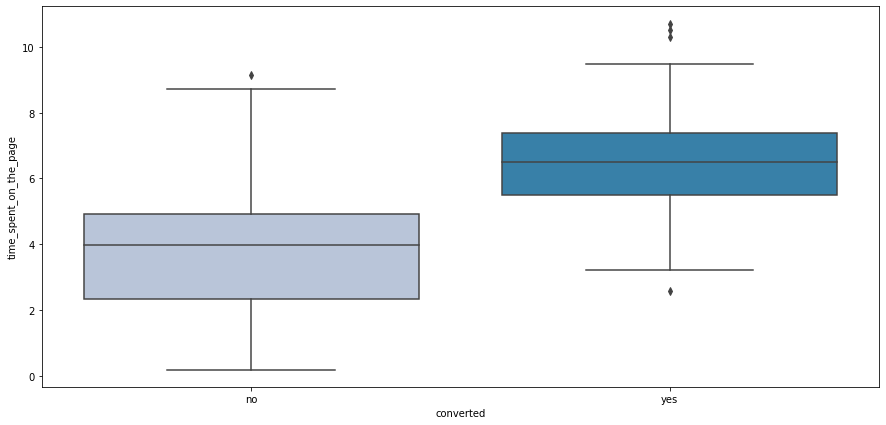

```python
plt.figure(figsize=(15,7))
sns.boxplot(df["converted"],df["time_spent_on_the_page"],palette="PuBu")
plt.show()
```

**Observations**

- Users who spent higher time on the page tends to subscribe the news portal camapred to who did less

#### time_spent_on_the_page vs language_preferred

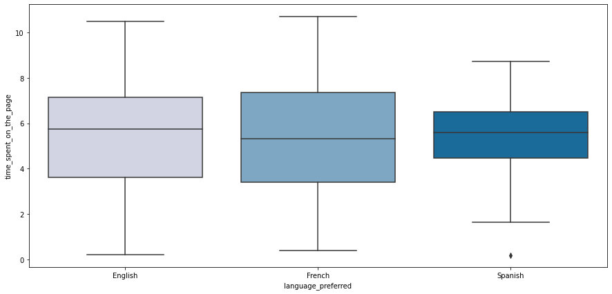

```python
plt.figure(figsize=(15,7))
sns.boxplot(df["language_preferred"],df["time_spent_on_the_page"],palette="PuBu")
plt.show()
```

#### Relationship between group, language_preferred, landing_page and time_spent_on_the_page

```python
df.groupby('language_preferred')['time_spent_on_the_page'].describe()
```

| language_preferred | count | mean | std | min | 25% | 50% | 75% | max |
| --- | --- | --- | --- | --- | --- | --- | --- | --- |
| English | 32.0 | 5.559063 | 2.621079 | 0.22 | 3.6175 | 5.755 | 7.1375 | 10.50 |
| French | 34.0 | 5.253235 | 2.675413 | 0.40 | 3.3950 | 5.315 | 7.3675 | 10.71 |
| Spanish | 34.0 | 5.331765 | 1.818095 | 0.19 | 4.4750 | 5.605 | 6.5150 | 8.72 |

```python
df.groupby('landing_page')['user_id'].describe()
```

| landing_page | count | mean | std | min | 25% | 50% | 75% | max |
| --- | --- | --- | --- | --- | --- | --- | --- | --- |
| new | 50.0 | 546467.5 | 14.57738 | 546443.0 | 546455.25 | 546467.5 | 546479.75 | 546492.0 |
| old | 50.0 | 546566.5 | 17.67767 | 546493.0 | 546555.25 | 546567.5 | 546579.75 | 546592.0 |

```python
df.groupby(by = ['language_preferred','landing_page'])['time_spent_on_the_page'].mean()
```

```
language_preferred  landing_page
English             new             6.663750
                    old             4.454375
French              new             6.196471
                    old             4.310000
Spanish             new             5.835294
                    old             4.828235
Name: time_spent_on_the_page, dtype: float64
```

```python
df.groupby(by = ['language_preferred','group'])['time_spent_on_the_page'].mean()
```

```
language_preferred  group
English             control      4.454375
                    treatment    6.663750
French              control      4.310000
                    treatment    6.196471
Spanish             control      4.828235
                    treatment    5.835294
Name: time_spent_on_the_page, dtype: float64
```

```python
df.groupby(by = ['language_preferred','converted'])['time_spent_on_the_page'].mean()
```

```
language_preferred  converted
English             no           3.810909
                    yes          6.474762
French              no           3.861579
                    yes          7.016000
Spanish             no           4.052500
                    yes          6.468889
Name: time_spent_on_the_page, dtype: float64
```

**Observations**

**Let's have a quick final overview of the data using the pandas profiling library.**

```python
# let us try pandas-profiling now and see how does it simplifies the EDA
# !pip install pandas-profiling==2.8.0
```

```python
from pandas_profiling import ProfileReport
# Use the original dataframe, so that original features are considered
prof = ProfileReport(data)
# to view report created by pandas profile
prof
```

[interactive chart not shown]

```python
# to save report obtained via pandas profiling
prof.to_file(output_file='output.html')
```

## Q.2: Do the users spend more time on the new landing page than the old landing page?

```python
df.groupby('landing_page')['time_spent_on_the_page'].describe()
```

| landing_page | count | mean | std | min | 25% | 50% | 75% | max |
| --- | --- | --- | --- | --- | --- | --- | --- | --- |
| new | 50.0 | 6.2232 | 1.817031 | 1.65 | 5.175 | 6.105 | 7.1600 | 10.71 |
| old | 50.0 | 4.5324 | 2.581975 | 0.19 | 2.720 | 4.380 | 6.4425 | 10.30 |

```python
# separate the time spent on the page with respect to the two lading page group
landing_page_new = df[df['landing_page']=='new']['time_spent_on_the_page']
landing_page_old = df[df['landing_page']=='old']['time_spent_on_the_page']
```

```python
landing_page_new.describe()
```

```
count    50.000000
mean      6.223200
std       1.817031
min       1.650000
25%       5.175000
50%       6.105000
75%       7.160000
max      10.710000
Name: time_spent_on_the_page, dtype: float64
```

```python
landing_page_old.describe()
```

```
count    50.000000
mean      4.532400
std       2.581975
min       0.190000
25%       2.720000
50%       4.380000
75%       6.442500
max      10.300000
Name: time_spent_on_the_page, dtype: float64
```

```python
landing_page_new.head()
```

```
1     7.13
2     4.40
4     4.75
6     5.25
8    10.71
Name: time_spent_on_the_page, dtype: float64
```

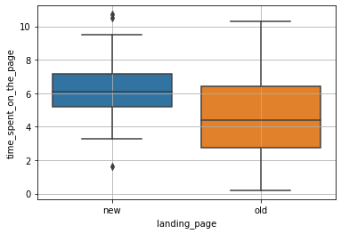

```python
# visual analysis of the time spent on the page for the two landing pages
sns.boxplot(x="landing_page", y="time_spent_on_the_page", data = df)
plt.grid()
plt.show()
```

- users in new landing page spent longer time than old landing page

### Conduct a hypothesis test to determine whether the users spend more time on the new landing page than the old landing page. Use level of significance as 5%

### Step 1: Define null and alternate hypotheses

$H_0:$ The mean time spent on new landing page is equal to the mean time spent on old landing page.

$H_a:$ The mean time spent on new landing page is greater than the mean time spent on old landing page.

Let $\mu_1$ and $\mu_2$ be the mean time spent on new landing page and the mean time spent on old landing page respectively.

Mathematically, the above formulated hypotheses can be written as:

$H_0: \mu_1 = \mu_2 $

$H_a: \mu_1 > \mu_2 $

### Step 2: Select Appropriate test

This is a case of a one-tailed two-sample mean test. As the two samples are independent in this case, and also the population standard deviations are unknown, we shall use a 2-sample ind. t-test for this problem.

### Step 3: Decide the significance level

As given in the problem statement, we select $\alpha$ = 0.05.

### Step 4: Calculate the p-value

```python
#import the required functions
from scipy.stats import ttest_ind

# find the p-value
test_stat, p_value = ttest_ind([landing_page_new.mean()], [landing_page_old.mean()], equal_var = False, alternative = 'greater')
print('The p-value is ', p_value)
```

```
The p-value is  nan
```

## Step 5: Compare the p-value with $\alpha$

```python
# print the conclusion based on p-value
if p_value < 0.05:
    print(f'As the p-value {p_value} is less than the level of significance, we reject the null hypothesis.')
else:
    print(f'As the p-value {p_value} is greater than the level of significance, we fail to reject the null hypothesis.')
```

```
As the p-value nan is greater than the level of significance, we fail to reject the null hypothesis.
```

## Q.3: Is the conversion rate (the proportion of users who visit the landing page and get converted) for the new page greater than the conversion rate for the old page?

```python
df.groupby(by = ['landing_page','converted'])['user_id'].count()
```

```
landing_page  converted
new           no           17
              yes          33
old           no           29
              yes          21
Name: user_id, dtype: int64
```

```python
new_landing_page_conversion_rate = 33/50
old_landing_page_conversion_rate = 21/50
```

```python
new_landing_page_conversion_rate, old_landing_page_conversion_rate
```

```
(0.66, 0.42)
```

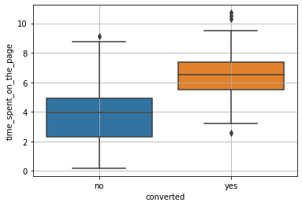

```python
# visual analysis of the time spent on the page for the two landing pages
sns.boxplot(x="converted", y="time_spent_on_the_page", data = df)
plt.grid()
plt.show()
```

- conversion rate for the new page is greater than the conversion rate of old page.

### Conduct a hypothesis test to determine whether the conversion rate (the proportion of users who visit the landing page and get converted) for the new page greater than the conversion rate for the old page? Use level of significance as 5%

### Step 1: Define null and alternate hypotheses

$H_0:$ The proportion of users who visit the new landing page and get converted is equal to the proportion of users who visit the old landing page and get converted

$H_a:$ The proportion of users who visit the new landing page and get converted is greater to the proportion of users who visit the old landing page and get converted

Mathematically, the above formulated hypotheses can be written as:

$H_0: \mu_1 = \mu_2 $

$H_a: \mu_1 > \mu_2 $

### Step 2: Select Appropriate test

The formulated hypotheses are concerned with proportions. A test of proportions can be used to analyse the hypotheses and draw a conclusion. We shall use a Proportions Z test for this problem.

### Step 3: Decide the significance level

As given in the problem statement, we select $\alpha$ = 0.05.

### Preparing data for test

```python
# number of user in new landing page converted as subscriber
new_landing_page = df[df['landing_page']=='new'].converted.value_counts()['yes']
# number of user in old landing page did not convert as subscriber
old_landing_page = df[df['landing_page']=='old'].converted.value_counts()['yes']

print('The numbers of converted and non converted are {0} and {1} respectively'.format(new_landing_page, old_landing_page))

# number of new landing page user in the data
n_new = df.landing_page.value_counts()['new']

# number of new landing page user in the data
n_old = df.landing_page.value_counts()['old']

print('The total numbers of new and old are {0} and {1} respectively'.format(n_new, n_old))
```

[output not shown]

```python
print(f' The proportions of converted and non-converted are {round(33/50,2)}, {round(21/50,2)} respectively')
```

[output not shown]

- The proportions in the sample are different. Let's conduct the test to see if this difference is significant.

### Step 4: Calculate the p-value

```python
# import the required function
from statsmodels.stats.proportion import proportions_ztest
```

```python
# find the p-value using proportion_ztest
stat, pval = proportions_ztest([new_landing_page, old_landing_page] , [n_new, n_old], alternative = 'two-sided')

# print the p-value
print('The p-value is '+ str(pval))
```

```
The p-value is 0.016052616408112556
```

### Step 5: Compare the p-value with $\alpha$

```python
# print the conclusion based on p-value
if pval < 0.05:
    print(f'As the p-value {pval} is less than the level of significance, we reject the null hypothesis.')
else:
    print(f'As the p-value {pval} is greater than the level of significance, we fail to reject the null hypothesis.')
```

```
As the p-value 0.016052616408112556 is less than the level of significance, we reject the null hypothesis.
```

### Step 6: Draw Inference

At 5% significance level, we reject the null hypothesis. Hence we do have enough statistical evidence to say that the conversion rate (the proportion of users who visit the landing page and get converted) for the new page greater than the conversion rate for the old page.

## Q.4: Does the converted status depend on the preferred language?

```python
df.groupby(by = ['language_preferred','converted'])['time_spent_on_the_page'].describe()
```

| language_preferred | converted | count | mean | std | min | 25% | 50% | 75% | max |
| --- | --- | --- | --- | --- | --- | --- | --- | --- | --- |
| English | no | 11.0 | 3.810909 | 2.548001 | 0.22 | 2.565 | 3.65 | 5.020 | 8.73 |
|  | yes | 21.0 | 6.474762 | 2.200267 | 2.58 | 5.280 | 6.52 | 7.460 | 10.50 |
| French | no | 19.0 | 3.861579 | 2.535368 | 0.40 | 1.865 | 3.68 | 4.810 | 9.15 |
|  | yes | 15.0 | 7.016000 | 1.627780 | 5.25 | 5.715 | 6.79 | 8.055 | 10.71 |
| Spanish | no | 16.0 | 4.052500 | 1.674385 | 0.19 | 3.335 | 4.43 | 4.940 | 6.70 |
|  | yes | 18.0 | 6.468889 | 1.016562 | 4.75 | 5.945 | 6.44 | 7.060 | 8.72 |

```python
from   scipy.stats import chi2_contingency   # For Chi-Square test
```

## Step 1: Define null and alternative hypotheses

𝐻0: Converted status is independent on the preferred language

𝐻𝑎: Converted status is not independent on the preferred language

## Step 2: Select Appropriate test

The formulated hypotheses can be tested using a Chi-square test of independence of attributes, concerning the two categorical variables.

## Step 3: Decide the significance level

Here, we select α= 0.05.